# Data Analytics

2024-04-02

## Assignment 2

## 20182543

ISLR 패키지의 Carseats 데이터셋은 유아용 카시트 판매회사의 400개의 상점에서의 카시트 판매량에 관한 데이 터로 구성된다.

• Sales : 각 상점에서의 판매량 (천 개)

• CompPrice : 각 상점에서 경쟁회사 제품의 가격

• Income : 상점이 위치한 지역의 소득 수준 ($1,000)

• Advertising : 상점이 위치한 지역에서의 광고 예산 ($1,000)

• Population : 상점이 위치한 지역의 인구 규모 (천 명)

• Price : 각 상점에서의 카시트 가격

• ShelveLoc : 각 상점에서 카시트가 좋은 위치에 진열되어 있는지 여부 (Bad, Good, and Medium)

• Age : 상점이 위치한 지역 인구의 평균 연령

• Education : 상점이 위치한 지역의 교육 수준

• Urban: 상점이 도시에 있는지 시골에 있는지 여부 (No and Yes)

• US : 상점이 미국 내에 있는지 여부 (No and Yes)

다음 코드를 통해서 Carseats 데이터프레임을 사용할 수 있다.

install.packages(“ISLR”)

library(ISLR)

?Carseats

str(Carseats)

```r
# 사용할 패키지 추가
library(class)
library(caret)
library(ggplot2)
library(dplyr)
library(ISLR)
```

```r
str(Carseats)
```

```
## 'data.frame':    400 obs. of  11 variables:
##  $ Sales      : num  9.5 11.22 10.06 7.4 4.15 ...
##  $ CompPrice  : num  138 111 113 117 141 124 115 136 132 132 ...
##  $ Income     : num  73 48 35 100 64 113 105 81 110 113 ...
##  $ Advertising: num  11 16 10 4 3 13 0 15 0 0 ...
##  $ Population : num  276 260 269 466 340 501 45 425 108 131 ...
##  $ Price      : num  120 83 80 97 128 72 108 120 124 124 ...
##  $ ShelveLoc  : Factor w/ 3 levels "Bad","Good","Medium": 1 2 3 3 1 1 3 2 3 3 ...
##  $ Age        : num  42 65 59 55 38 78 71 67 76 76 ...
##  $ Education  : num  17 10 12 14 13 16 15 10 10 17 ...
##  $ Urban      : Factor w/ 2 levels "No","Yes": 2 2 2 2 2 1 2 2 1 1 ...
##  $ US         : Factor w/ 2 levels "No","Yes": 2 2 2 2 1 2 1 2 1 2 ...
```

```r
df = Carseats
```

```r
# 결측치 제거
df <- na.omit(df)

#첫 100개의데이터만 사용
df <- df[1:100,]
```

min max 정규화 함수

```r
normalize <- function(x) {
 return ((x - min(x)) / (max(x) - min(x)))
}
normalize
```

```
## function(x) {
##  return ((x - min(x)) / (max(x) - min(x)))
## }
```

특정 컬럼의 단위가 과대 혹은 과소할 경우 예측 결과에 영향을 미치기 때문에 타겟 컬럼을 제외한 나머지 컬럼은 min-max 스케일링 진행

```r
# 타겟 변수 제외하고 min_max 정규화
df <- df %>%
  select(-Sales) %>%
  mutate_if(is.numeric, normalize) %>%
  bind_cols(df %>% select(Sales))  # 정규화된 데이터프레임에 원래의 타겟 변수를 다시 붙임

str(df)
```

```
## 'data.frame':    100 obs. of  11 variables:
##  $ CompPrice  : num  0.726 0.405 0.429 0.476 0.762 ...
##  $ Income     : num  0.526 0.268 0.134 0.804 0.433 ...
##  $ Advertising: num  0.458 0.667 0.417 0.167 0.125 ...
##  $ Population : num  0.528 0.496 0.514 0.915 0.659 ...
##  $ Price      : num  0.738 0.454 0.431 0.562 0.8 ...
##  $ ShelveLoc  : Factor w/ 3 levels "Bad","Good","Medium": 1 2 3 3 1 1 3 2 3 3 ...
##  $ Age        : num  0.309 0.727 0.618 0.545 0.236 ...
##  $ Education  : num  0.875 0 0.25 0.5 0.375 0.75 0.625 0 0 0.875 ...
##  $ Urban      : Factor w/ 2 levels "No","Yes": 2 2 2 2 2 1 2 2 1 1 ...
##  $ US         : Factor w/ 2 levels "No","Yes": 2 2 2 2 1 2 1 2 1 2 ...
##  $ Sales      : num  9.5 11.22 10.06 7.4 4.15 ...
```

범주형 컬럼이 존재, Label Encoding 진행

```r
# 범주형 변수 label encoding
df$ShelveLoc <- as.integer(factor(df$ShelveLoc))
df$Urban <- as.integer(factor(df$Urban))
df$US <- as.integer(factor(df$US))
```

```r
df
```

|  | CompPrice | Income | Advertising | Population | Price | ShelveLoc | Age | Education | Urban | US | Sales |
| --- | --- | --- | --- | --- | --- | --- | --- | --- | --- | --- | --- |
| 1 | 0.7261905 | 0.52577320 | 0.45833333 | 0.528455285 | 0.7384615 | 1 | 0.30909091 | 0.875 | 2 | 2 | 9.50 |
| 2 | 0.4047619 | 0.26804124 | 0.66666667 | 0.495934959 | 0.4538462 | 2 | 0.72727273 | 0.000 | 2 | 2 | 11.22 |
| 3 | 0.4285714 | 0.13402062 | 0.41666667 | 0.514227642 | 0.4307692 | 3 | 0.61818182 | 0.250 | 2 | 2 | 10.06 |
| 4 | 0.4761905 | 0.80412371 | 0.16666667 | 0.914634146 | 0.5615385 | 3 | 0.54545455 | 0.500 | 2 | 2 | 7.40 |
| 5 | 0.7619048 | 0.43298969 | 0.12500000 | 0.658536585 | 0.8000000 | 1 | 0.23636364 | 0.375 | 2 | 1 | 4.15 |
| 6 | 0.5595238 | 0.93814433 | 0.54166667 | 0.985772358 | 0.3692308 | 1 | 0.96363636 | 0.750 | 1 | 2 | 10.81 |
| 7 | 0.4523810 | 0.85567010 | 0.00000000 | 0.058943089 | 0.6461538 | 3 | 0.83636364 | 0.625 | 2 | 1 | 6.63 |
| 8 | 0.7023810 | 0.60824742 | 0.62500000 | 0.831300813 | 0.7384615 | 2 | 0.76363636 | 0.000 | 2 | 2 | 11.85 |
| 9 | 0.6547619 | 0.90721649 | 0.00000000 | 0.186991870 | 0.7692308 | 3 | 0.92727273 | 0.000 | 1 | 1 | 6.54 |
| 10 | 0.6547619 | 0.93814433 | 0.00000000 | 0.233739837 | 0.7692308 | 3 | 0.92727273 | 0.875 | 1 | 2 | 4.69 |

[output cut: 90 more lines]

```r
library(rsample)
```

문제1 : Stratified sampling을 통해 traing set과 test set을 70:30 비율로 분할하고, 두 set에서의 target 변수의 분포를 비교해보자

```r
# Stratified sampling을 통해 traing set과 test set을 7:3 비율로 분할

set.seed(42)

split <- initial_split(df, prop = 0.7, strata = "Sales")
df_train <- training(split)
df_test <- testing(split)
```

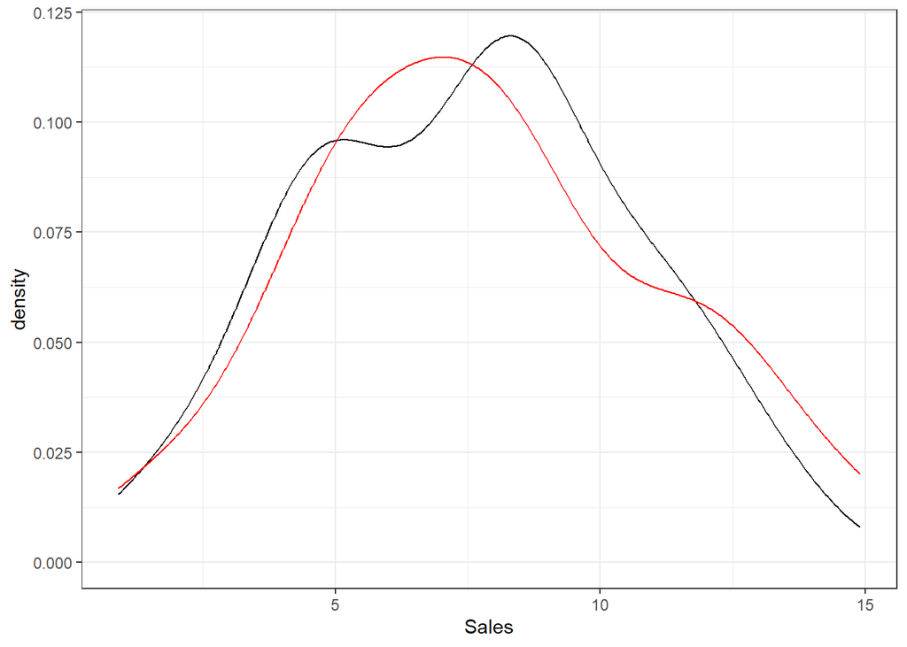

```r
#train, test 셋에서의 타겟 변수 Sales 에 대한 분포

ggplot(data = df_train, aes(x = Sales)) + geom_density() +
  geom_density(data = df_test, aes(x = Sales), color = 'red') + theme_bw()
```

해당 그래프를 보았을때 train과 test 셋에서 target 변수의 분포는 유사하다고 볼 수 있다

문제 2 : k-nn 을 적용한다. 이때 5-fold CV를 사용하여 parameter k의 값을 결정해 보고자한다. CV의 반복횟수 를 1, 5, 10, 15, 20으로 점점 증가시켜 본다. 어떠한 경향을 관찰할 수 있는가? best k 값, k 값의 변화에 따른 RMSE의 변화 그래프 등을 비교해본다. 그리고 최종적으로 best k 값을 합리적으로 결정하자.

cv = 5일 때

```r
#시드 고정
set.seed(42)
cv <- trainControl(method="repeatedcv", number=5, repeats=5)
tune_grid <- expand.grid(k = seq(1, 99, 2))

#정규화
z_normalized <- c("center", "scale")
knn_cv5 <- train(data = df_train, Sales~., method="knn", trControl = cv,
preProcess = z_normalized, tuneGrid = tune_grid)

knn_cv5
```

```
## k-Nearest Neighbors
##
## 68 samples
## 10 predictors
##
## Pre-processing: centered (10), scaled (10)
## Resampling: Cross-Validated (5 fold, repeated 5 times)
## Summary of sample sizes: 55, 55, 55, 54, 53, 54, ...
## Resampling results across tuning parameters:
##
##   k   RMSE      Rsquared    MAE
##    1  3.055607  0.25515157  2.562569
##    3  2.577218  0.31277168  2.163429
##    5  2.593099  0.31994896  2.169577
##    7  2.634945  0.28548837  2.193881
```

[output cut: 49 more lines]

cv = 5 일 때, 최적의 k = 3

```r
set.seed(42)

# repeats 값들 정의
repeat_num <- c(1, 5, 10, 15, 20)
tune_grid <- expand.grid(k = seq(1, 99, 2))

# 결과 저장할 데이터 프레임 생성
results <- data.frame(repeats = numeric(),
                      optimal_k = numeric(),
                      rmse = numeric())

# 각 cv 값에 대해 모델 생성하고 결과 저장
for (repeat_val in repeat_num) {
  set.seed(42)
  cv <- trainControl(method = "repeatedcv", number = 5, repeats = repeat_val)
  knn_fit <- train(data = df_train, Sales ~ ., method = "knn", trControl = cv,
                   preProcess = z_normalized, tuneGrid = tune_grid)

  # 최적의 모델 선택
  best_model <- knn_fit$bestTune
  optimal_k <- best_model$k

  # RMSE 계산
  rmse <- knn_fit$results[which.min(knn_fit$results$RMSE), "RMSE"]

  # 결과 저장
  results <- rbind(results, data.frame(repeats = repeat_val,
                                       optimal_k = optimal_k,
                                       rmse = rmse))
}

# 결과 출력
print(results)
```

```
##   repeats optimal_k     rmse
## 1       1         5 2.562563
## 2       5         3 2.577218
## 3      10         5 2.568609
## 4      15         5 2.581235
## 5      20         5 2.579317
```

[figure not shown]

```r
#시드 고정
set.seed(42)

cv <- trainControl(method="repeatedcv", number=5, repeats=5)
tune_grid <- expand.grid(k = seq(1, 99, 2))

#정규화
z_normalized <- c("center", "scale")
knn_cv5 <- train(data = df_train, Sales~., method="knn", trControl = cv,
preProcess = z_normalized, tuneGrid = tune_grid)


ggplot(knn_cv5) + labs(x = "k", y = "RMSE", title = "KNN",subtitle = "5-fold, 10 repeats Cross Validation") + theme_bw()
```

문제 3

2번에서 k-nn 모델의 best k를 선택할 때 사용한 동일한 CV 세팅에 대해, 10개의 feature들을 모두 사 용하는 linear regression 모델의 성능을 평가해보자. RMSE 기준으로 k-nn과 linear regression 중 어떤 모델이 더 우수한가?

cv = 10, k = 5

```r
set.seed(42)

cv <- trainControl(method = "repeatedcv", number = 5, repeats = 10)
model_lm <- train(form = Sales ~ ., data = df_train, method = "lm", trControl = cv)

model_lm
```

```
## Linear Regression
##
## 68 samples
## 10 predictors
##
## No pre-processing
## Resampling: Cross-Validated (5 fold, repeated 10 times)
## Summary of sample sizes: 55, 55, 55, 54, 53, 54, ...
## Resampling results:
##
##   RMSE      Rsquared   MAE
##   2.017683  0.5993671  1.629797
##
## Tuning parameter 'intercept' was held constant at a value of TRUE
```

```r
set.seed(42)


cv <- trainControl(method="repeatedcv", number=5, repeats=10)
tune_grid <- expand.grid(k = 5)
#정규화
z_normalized <- c("center", "scale")
model_knn <- train(data = df_train, Sales~., method="knn", trControl = cv,
preProcess = z_normalized, tuneGrid = tune_grid)

model_knn
```

```
## k-Nearest Neighbors
##
## 68 samples
## 10 predictors
##
## Pre-processing: centered (10), scaled (10)
## Resampling: Cross-Validated (5 fold, repeated 10 times)
## Summary of sample sizes: 55, 55, 55, 54, 53, 54, ...
## Resampling results:
##
##   RMSE      Rsquared   MAE
##   2.568609  0.3140501  2.14587
##
## Tuning parameter 'k' was held constant at a value of 5
```

Linear Regression model의 RMSE가 더 낮으므로 Linear Regression 모델이 더 우수하다고 할 수 있다.

문제4 : 두 모델 중 우수한 모델을 test set에 적용해보자. CV에서 계산된 RMSE와 test set에 대한 RMSE 값을 비교해보자. 두 값이 충분히 유사한가? 그렇지 않은가? 결과를 분석해보자.

knn 모델 예측

```r
carseats_knn_pred <- predict(model_knn, df_test)
carseats_knn_pred
```

```
##  [1]  8.380  6.254  6.836  7.924  6.762  8.080  5.372  6.094  8.988  8.260
## [11]  9.530  6.646  7.324  7.528  5.622  7.700 11.474  7.014  6.662  7.306
## [21]  6.712  7.982  8.028  5.524  9.448  8.960  6.086  8.376  7.822  8.740
## [31]  7.234  6.426
```

lm 모델 예측

```r
carseats_lm_pred <- predict(model_lm, df_test)
carseats_lm_pred
```

```
##        22        24        26        31        33        38        41        42
##  9.091341  4.788142  9.790960 10.390511  3.541148  7.094251  3.207195  7.510816
##        43        46        47        48        49        51        56        57
##  9.993226  4.714367 14.839057  6.517017  5.070204  5.651394  5.201553 10.496816
##        61        62        66        68        70        71        72        75
## 11.015336  6.118532  4.155630  9.876599  7.722419  6.473110  8.887869  7.540060
##        76        81        82        83        87        88        92        96
## 11.601499 11.401771  3.051415  8.571907  9.982796  7.091401  5.145192  5.300101
```

knn 모델 예측 RMSE

```r
knn_rmse = sqrt(mean((carseats_knn_pred - df_test$Sales)^2))

knn_rmse
```

```
## [1] 2.989707
```

lm 모델 예측 RMSE

```r
lm_rmse = sqrt(mean((carseats_lm_pred - df_test$Sales)^2))

lm_rmse
```

```
## [1] 2.460993
```

RMSE 값 자체가 표본 평균과의 차이를 나타내기 때문에 특별한 가정 없이 정규성을 따르는 경우가 많으므로 t-test 사용

```r
# 두 RMSE 값의 차이
diff_rmse <- knn_rmse - lm_rmse

# 두 RMSE 값의 차이에 대한 표준 오차
standard_error <- sqrt((knn_rmse^2 / 2) + (lm_rmse^2 / 2))

# t-검정을 통한 두 RMSE 값의 차이의 유의성 검정
t_value <- diff_rmse / standard_error
df <- min(length(df_test$Sales) - 1, length(carseats_knn_pred) - 1, length(carseats_lm_pred) - 1) # 자유도
p_value <- 2 * pt(abs(t_value), df = df, lower.tail = FALSE) # 양측 검정

# 결과 출력
cat("두 RMSE 값의 차이:", diff_rmse, "\n")
```

```
## 두 RMSE 값의 차이: 0.5287141
```

```r
cat("표준 오차:", standard_error, "\n")
```

```
## 표준 오차: 2.738141
```

```r
cat("t-value:", t_value, "\n")
```

```
## t-value: 0.1930924
```

```r
cat("p-value:", p_value, "\n")
```

```
## p-value: 0.8481462
```

```r
# 유의수준 0.05로 가정하고 검정 결과 출력
if (p_value < 0.05) {
  cat("두 RMSE 값의 차이는 통계적으로 유의합니다.\n")
} else {
  cat("두 RMSE 값의 차이는 통계적으로 유의하지 않습니다.\n")
}
```

```
## 두 RMSE 값의 차이는 통계적으로 유의하지 않습니다.
```

p_value가 0.05 보다 크므로 두 RMSE 값의 차이는 통계적으로 유의하지 않음

전체데이터에서 100개만을 추출해 사용해서 두 모델의 차이가 적게 나왔다고 생각한다. 또한 임의로 추출한 100개가 전체 데이터셋을 대표할 수 있다는 근거가 부족하기에 두 모델에 대한 신뢰성을 확보하기에는 어렵다. knn모델 사용시 범주형 변수를 수치형으로 변환해서 사용하는 것은 순서 혹은 간격에 의미가 없는 범주에 임의로 숫자를 배정한 것이므로 모델에 좋지 않은 영향을 미친다. 따라서 데이터 셋이 커지면 커질 수록 두 모델의 성능 차이는 더욱 명확하게 나타날 것이라 생각된다. 또한 회귀 모델일때 다중공선성을 고려하는 경우가 일반적인데 해당 프로젝트는 다중공선성을 고려하지 않았다. 다중공선성을 고려한다면 결과가 달라질 수도 있을 것이라 생각된다.